# Reproducible Research - Project 1 Documentation

Karolina Kosinska

1. Loading and preprocessing the data
- Required packages: dplyr, magrittr, ggplot2
- Load the data

```r
    activityData<-read.csv("C:/Users/kkosins/Desktop/Coursera Data Science/Data Science Reporting in R/Project 1/activity.csv", header = TRUE)
```

2. What is mean total number of steps taken per day?  
   For this part of the assignment, the missing values in the dataset are ignored.
- Calculate the total number of steps taken per day

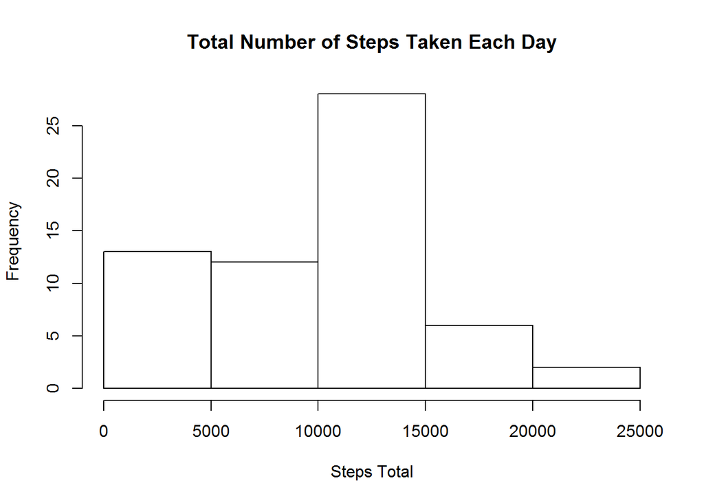

```r
      #Histogram of the total number of steps taken each day
      #Aggregating data - sum by day
      DailyStepsData<-activityData %>%
        group_by(date) %>%
          summarise(total_daily=sum(steps, na.rm=TRUE)) #%>%
          #filter(total_daily!="NA")
      #Histogram
      with(DailyStepsData, hist(DailyStepsData$total_daily,
                               main="Total Number of Steps Taken Each Day",
                               xlab="Steps Total",
                               ylab="Frequency"))
```

- Calculate and report the mean and median of the total number of steps taken per day

```r
      mean_daily<- round(mean(DailyStepsData$total_daily, na.rm=TRUE), 0)
      median_daily<- median(DailyStepsData$total_daily, na.rm=TRUE)
```

- **Mean of the total number of steps taken per day is 9354.**
- **Median of the total number of steps taken per day is 10395.**
3. What is the average daily activity pattern?
- Time series plot of the 5-minute interval (x-axis) and the average number of steps taken, averaged across all days (y-axis)

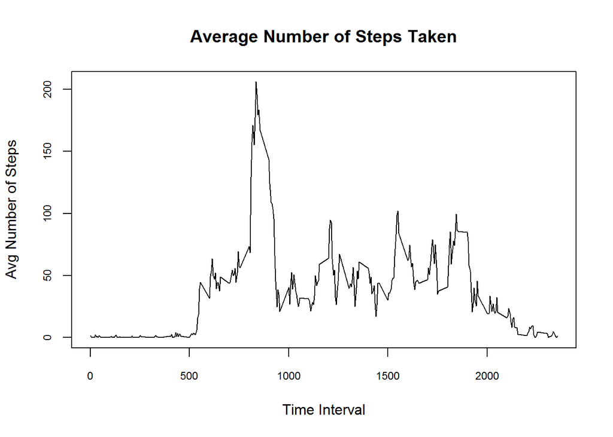

```r
#Aggregating data - average by interval
AvgStepsData<-activityData %>%
  group_by(interval) %>%
  summarise(avg_daily=mean(steps, na.rm=TRUE))
#Time Series plot
with(AvgStepsData, plot(x=AvgStepsData$interval, y=AvgStepsData$avg_daily, type = "l",
                        main="Average Number of Steps Taken",
                        xlab="Time Interval",
                        ylab="Avg Number of Steps",
                        cex.axis=0.75))
```

```r
#The 5-minute interval that, on average, contains the maximum number of steps
maxInterval<-AvgStepsData$interval[AvgStepsData$avg_daily==max(AvgStepsData$avg_daily)]
```

- 835 is 5-minute interval, on average across all the days in the dataset, contains the maximum number of steps.
4. Imputing missing values
- Calculate and report the total number of missing values in the dataset

```r
#Calculate and report the total number of missing values in the dataset
numberOfNAs<-sum(is.na(activityData[,1]))
```

- **Total number of missing values is 2304**
- Devise a strategy for filling in all of the missing values in the dataset. The strategy does not need to be sophisticated. For example, you could use the mean/median for that day, or the mean for that 5-minute interval, etc.
- **Missing steps values will be replaced by average number of steps for 5-minute interval.**
- Create a new dataset that is equal to the original dataset but with the missing data filled in.

```r
#Average number of Steps taken in each 5-minute interval, rounded to the whole numbers
AvgStepsData$AvgStepsInteger<-round(AvgStepsData$avg_daily, digits = 0)
#Creating new data table with activity data and avg number of steps (left join)
activityData_noMissing<- left_join(activityData, AvgStepsData, by="interval")
#Replacing NA values in steps column with avgeage steps value for interval accordingly (avg rounded
#   to zero decimal places)
activityData_noMissing$steps_repl_na<-
    ifelse(is.na(activityData_noMissing$steps),
      activityData_noMissing$AvgStepsInteger,
      activityData_noMissing$steps)
#Creating a new dataset that is equal to the original dataset but with the missing data filled in
activityData_noMissing<-activityData_noMissing[,c(2,3,6)]
```

- Make a histogram of the total number of steps taken each day and Calculate and report the mean and median total number of steps taken per day. Do these values differ from the estimates from the first part of the assignment? What is the impact of imputing missing data on the estimates of the total daily number of steps?

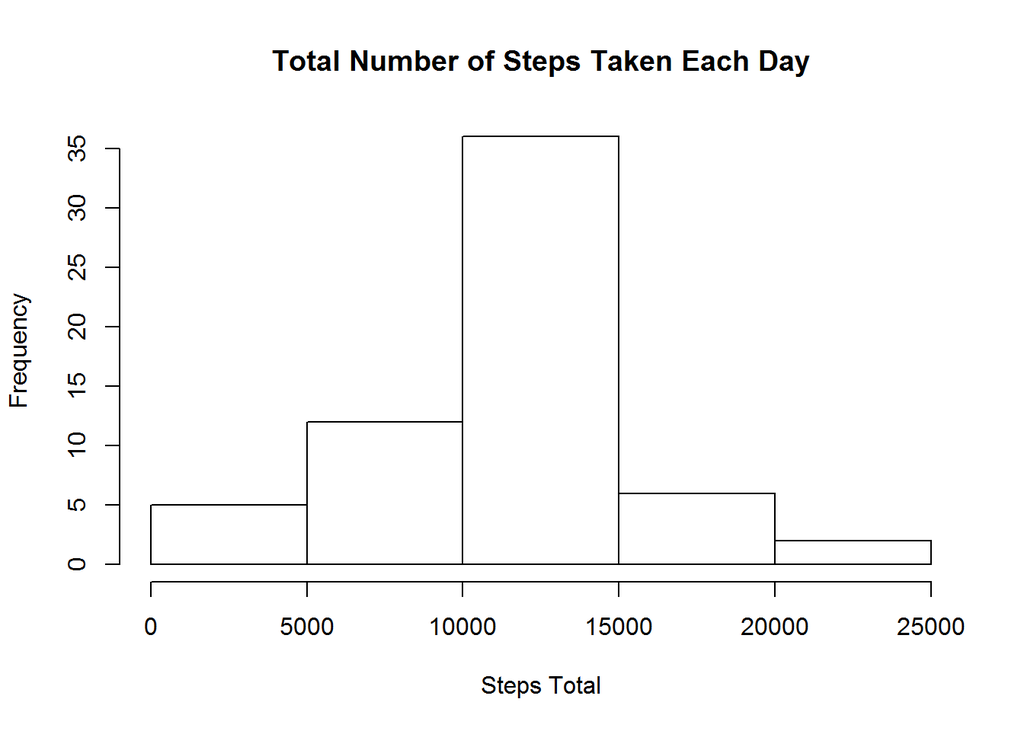

```r
#Aggregating data - sum by day
DailyStepsData_noNA<-activityData_noMissing %>%
  group_by(date) %>%
  summarise(total_daily=sum(steps_repl_na))
#Histogram
with(DailyStepsData_noNA, hist(DailyStepsData_noNA$total_daily,
                          main="Total Number of Steps Taken Each Day",
                          xlab="Steps Total",
                          ylab="Frequency"))
```

```r
#Mean and median total number of steps taken per day
StatsStepsPerDay2<- DailyStepsData_noNA %>%
  summarise(mean_daily=mean(total_daily, na.rm=TRUE), median_daily=median(total_daily, na.rm=TRUE))
```

- **Mean of the total number of steps taken per day is 10766.**
- **Median of the total number of steps taken per day is 10762.**
- **After replcing missing values from original dataset with avergaes for 5-minute intervals, more datapoints in column ‘steps’ are available and taken into account when calculating mean and median, so ultimately those values changed comapring to the values from the first part of the assignment.**
5. Are there differences in activity patterns between weekdays and weekends?
- Create a new factor variable in the dataset with two levels - “weekday” and “weekend” indicating whether a given date is a weekday or weekend day.

```r
#Create a new factor variable in the dataset with two levels - "weekday" and "weekend"
# indicating whether a given date is a weekday or weekend day.
activityData_noMissing$day<- ifelse(weekdays(as.Date(activityData_noMissing$date))=="Saturday" |
                                    weekdays(as.Date(activityData_noMissing$date))=="Sunday",
                                             "weekend", "weekday")
```

- Make a panel plot containing a time series plot of the 5-minute interval (x-axis) and the average number of steps taken, averaged across all weekday days or weekend days (y-axis).

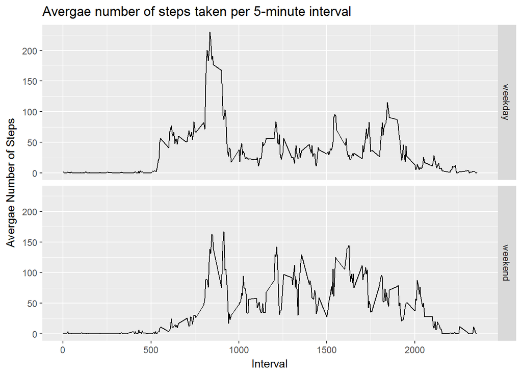

```r
#Aggregating data - average by interval
avgSteps_weekday_weekend<- activityData_noMissing %>%
                                  group_by(interval, day) %>%
                                    summarise(avgSteps=mean(steps_repl_na))
#Panel plot
ggplot(data=avgSteps_weekday_weekend, aes(x=interval, y=avgSteps)) +
  geom_line() +
  facet_grid(day ~.) +
  labs(title="Avergae number of steps taken per 5-minute interval",
       x="Interval", y="Avergae Number of Steps")
```